# Analyse Lösung vom Effekt Rassenkombination vs Heterosis/Rekombination

Sophie Kunz

30 4 2020

```r
library(dplyr)
```

```r
library(ggplot2)
```

# Hintergrund

Aus den Ergebnissen der Modellselektion hat sich rausgestellt, dass sowohl der fixen Effekt Rassenkombination wie auch Heterosis und Rekombination im Modell für alle Schlachtmerkmale enthalten sollten. Dieses Ergebnis ist unerwartet.

# Ziel

Analyse aus dem gesamten Datensatz von den Lösung aus der Modellselektion für Rassenkombination sowie Heterosis und Rekombination.

# Vorgehen

Der Merkmalsblock Schlachtgewicht wurde ausgewählt, da es ist der “sauberste” erhobene Merkmal. Dann wird die Lösung vom Effekt Rassenkombination und entsprechend Heterosis und Rekombination wo die Rassenkombination am meisten Beobachtungen enthält. Mit dem wird erhofft einerseits die Lösung wie auch die Logik von Effekt kontrolliert.

# Analyse

Die wichtigsten Rassenkombination nach Effektstuffen sortieren:

```
## # A tibble: 31 x 2
##    breedcomb      n
##        <dbl>  <int>
##  1         4 138694
##  2         1  74443
##  3        15  50063
##  4        16  34322
##  5        23  23617
##  6         9  21000
##  7        26  16147
##  8         8  11659
##  9        19  11013
## 10        10  10563
## # … with 21 more rows
```

Gemäss `log_CarcassPlausibilisieren` bedeuten die wichtigsten Effekt nach absteigende Anzahl Beobachtung folgendes:

```r
#Absteigende Beobachtung pro Effektstuffe
#Effect Key = BV.BV Effect Code = 4 Number of obs for Effect = 138694
#Effect Key = LM.BV Effect Code = 1 Number of obs for Effect = 74443
#Effect Key = HO.HO Effect Code = 15 Number of obs for Effect = 50063
#Effect Key = LM.KR Effect Code = 16 Number of obs for Effect = 34322
#Effect Key = LM.HO Effect Code = 23 Number of obs for Effect = 23617
#Effect Key = SI.SI Effect Code = 9 Number of obs for Effect = 21000
#Effect Key = UF.BV Effect Code = 26 Number of obs for Effect = 16147
#Effect Key = LM.SF Effect Code = 8 Number of obs for Effect = 11659
#Effect Key = AN.AN Effect Code = 19 Number of obs for Effect = 11013
#Effect Key = LM.SI Effect Code = 10 Number of obs for Effect = 10563

#Die ersten Effekten
#Effect Key = LM.BV Effect Code = 1 Number of obs for Effect = 74443
#Effect Key = HO.SF Effect Code = 2 Number of obs for Effect = 7237
#Effect Key = SF.SF Effect Code = 3 Number of obs for Effect = 9975
#Effect Key = BV.BV Effect Code = 4 Number of obs for Effect = 138694
#Effect Key = AN.BV Effect Code = 5 Number of obs for Effect = 4116
#Effect Key = BD.BV Effect Code = 6 Number of obs for Effect = 5823
#Effect Key = SI.BV Effect Code = 7 Number of obs for Effect = 9074
#Effect Key = LM.SF Effect Code = 8 Number of obs for Effect = 11659
#Effect Key = SI.SI Effect Code = 9 Number of obs for Effect = 21000
#Effect Key = LM.SI Effect Code = 10 Number of obs for Effect = 10563
```

## Modellselektion mit dem Merkmal Schlachtgewicht Grossviehmast

Aufpassen die Einheit vom Schlachtgewicht ist nicht kg, sondern kg/100. Dies ist mit der Interpretation der Lösung zu beachten. Die Lösung für Schlachtgewicht Grossviehmast `cwao` bei der Modellselektion beobachten:

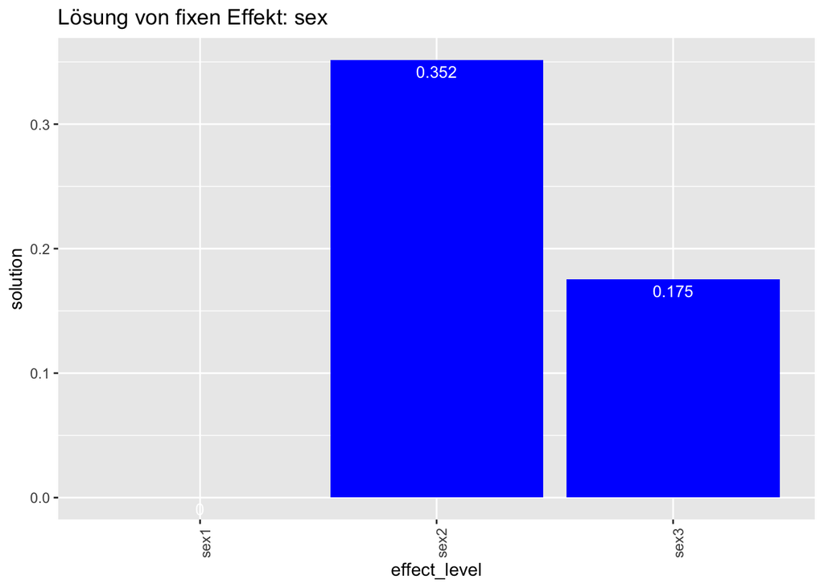

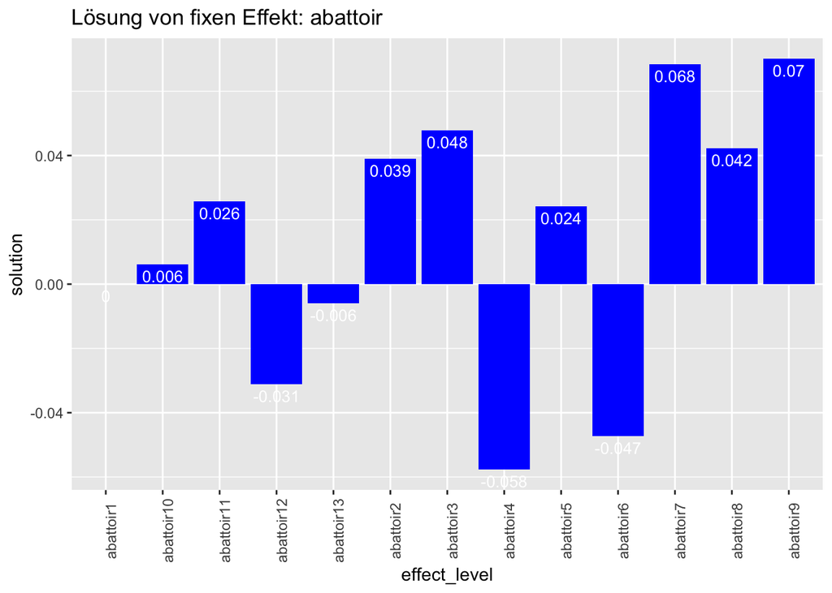

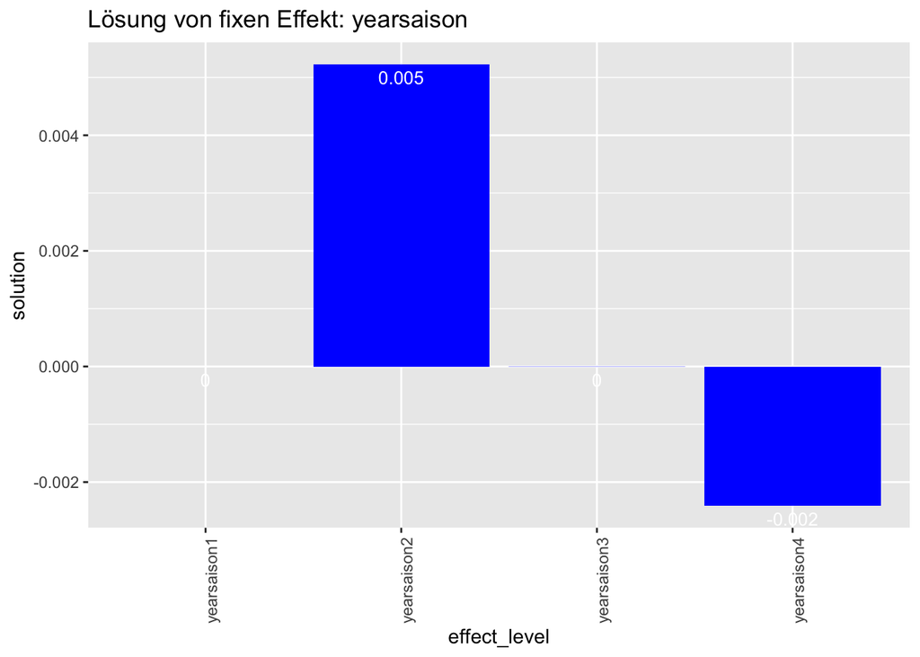

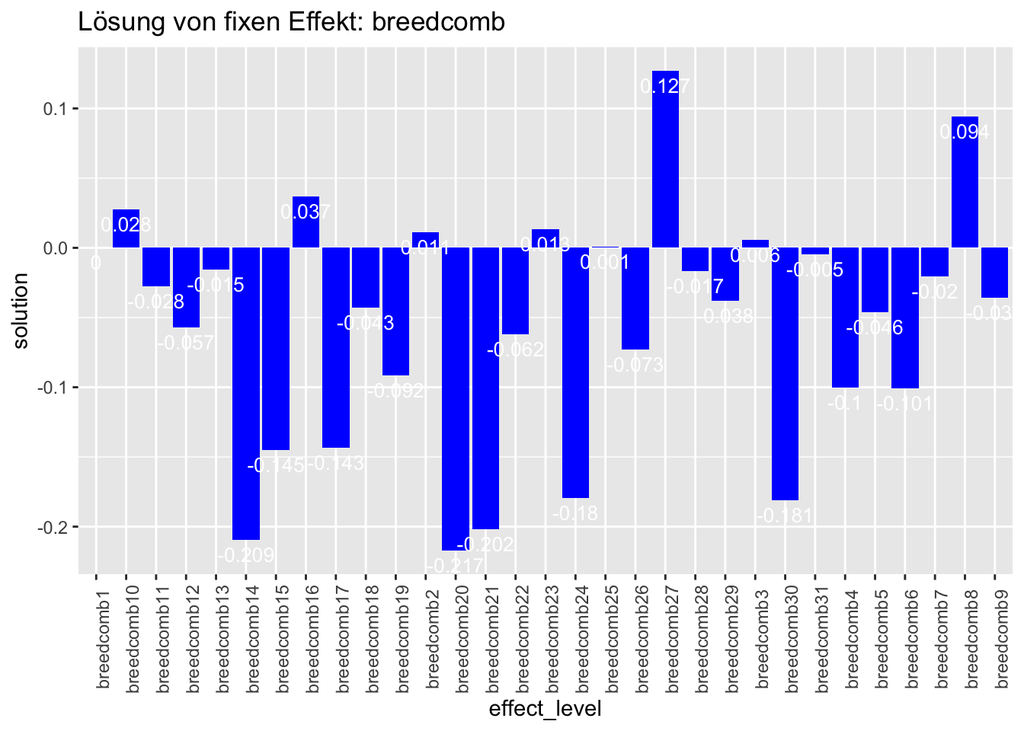

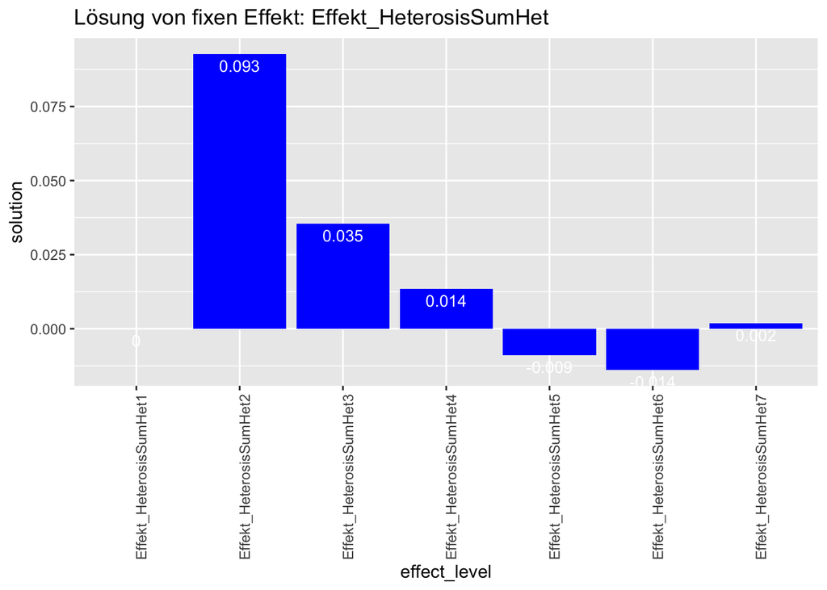

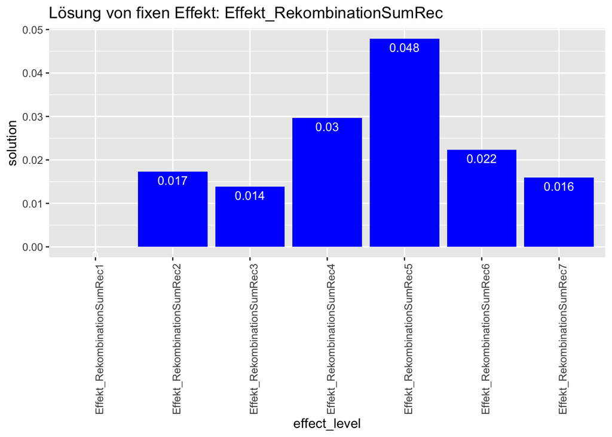

Die Effektstuffe 1 von alle Effekte ist immer auf 0 gesetzt. Grund dafür ist, dass das Modell der Unterschied von Effekt2 zu Effekt1, Effekt3 zu Effekt1, etc macht. Beispiel mit Effekt sex wobei die Effektstuffen folgendes bedeuten:

- Effekt sex1 = weiblich
- Effekt sex2 = männlich
- Effekt sex3 = kastrat

Interpretation von dem Resultat von den Balken ist:

- sex2 (männlich) hat einen Effekt von 35.2 kg im Vergleich zum Effekt sex1 (weiblich)
- sex3 (kastrat) hat einen Effekt von 17.5 kg im Vergleich zum Effekt sex1(weiblich)

Die Frage stellt sich nachher für jedem Effekt, ob diese Lösung Sinn machen sei es genetisch wie auch biologisch gesehen?

Dort wo es am meisten Unterschied gibt, ist bei Rassenkombination. Deswegen werden die Phänotypen davon angeschaut.

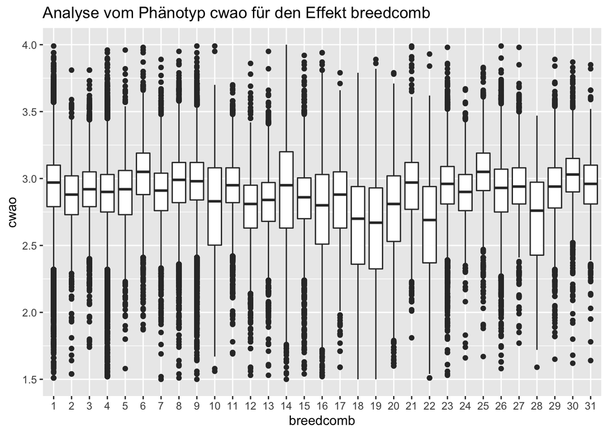